# Probability of Stopping Out of a Trade

## First-Passage Time Analysis with Two Barriers

**Question posed by colleague:**  
Given a long HKD/USD trade entered at **7.84**, take-profit at **7.85**, stop-loss at **7.78**,  
with the currency pegged in the band [7.75, 7.85] — what is the probability of being stopped out?

We generalize this to any trade given a **volatility input** (implied or historical).

### Mathematical Framework

We model the price as **Arithmetic Brownian Motion** (appropriate for a pegged currency in a tight band):

$$dS = \mu \, dt + \sigma \, dW_t$$

We want the probability that $S$ hits the **lower barrier** $L$ (stop-loss) before the **upper barrier** $U$ (take-profit), starting at $S_0$.

This is a classic **two-barrier first-passage problem**. The probability $u(x) = P(\text{hit } L \text{ before } U \mid S_0 = x)$ satisfies the ODE:

$$\mu \, u'(x) + \frac{\sigma^2}{2} u''(x) = 0$$

with boundary conditions $u(L) = 1$, $u(U) = 0$.

**Closed-form solution:**

$$ P(\text{stop out}) = \begin{cases} \dfrac{U - S_0}{U - L} & \text{if } \mu = 0 \\[12pt] \dfrac{e^{\theta(U - S_0)} - 1}{e^{\theta(U - L)} - 1} & \text{if } \mu \neq 0 \end{cases} $$

where $\theta = \dfrac{2\mu}{\sigma^2}$.

> **Note:** This is the *infinite-horizon* probability — it asks which barrier gets hit first, regardless of when. It does not require specifying a time horizon, which is natural for a pegged currency where the position is held until one barrier is hit.

```python
import numpy as np
import matplotlib.pyplot as plt
import matplotlib.gridspec as gridspec
from scipy.stats import norm

plt.style.use('seaborn-v0_8-whitegrid')
plt.rcParams['figure.dpi'] = 120
plt.rcParams['font.size'] = 11
```

## 1. Analytical Formula

```python
def prob_stop_out_analytical(entry: float, stop: float, target: float,
                              mu: float = 0.0, sigma: float = None,
                              annualized_vol: float = None,
                              annualized_drift: float = 0.0) -> dict:
    """
    Compute the probability of hitting stop-loss before take-profit
    using the two-barrier first-passage time formula.

    This is the INFINITE-HORIZON probability: which barrier gets hit first,
    regardless of when. No time horizon needed.

    Parameters
    ----------
    entry            : float  — entry price (S0)
    stop             : float  — stop-loss level (L), must be < entry
    target           : float  — take-profit level (U), must be > entry
    mu               : float  — instantaneous drift (price units per year)
    sigma            : float  — instantaneous vol (price units per sqrt(year))
    annualized_vol   : float  — annualized vol in % terms (e.g. 0.02 = 2%),
                                alternative to sigma; sigma = annualized_vol * entry
    annualized_drift : float  — annualized drift in % terms (e.g. 0.0 = flat)
                                alternative to mu; mu = annualized_drift * entry

    Returns
    -------
    dict with:
        p_stop_out   : P(hit stop before target)
        p_take_profit: P(hit target before stop)
        theta        : 2*mu/sigma^2 (the drift-vol ratio)
        dist_to_stop : |entry - stop|
        dist_to_tp   : |target - entry|
        risk_reward  : dist_to_tp / dist_to_stop
    """
    assert stop < entry < target, "Must have: stop < entry < target"

    # Convert annualized % vol/drift to price-unit terms if provided
    if annualized_vol is not None:
        sigma = annualized_vol * entry
    if annualized_drift != 0.0:
        mu = annualized_drift * entry

    L, S0, U = stop, entry, target
    c = S0 - L   # distance from entry to stop (positive)
    d = U - S0   # distance from entry to target (positive)

    if sigma is None or sigma == 0:
        raise ValueError("Must provide sigma or annualized_vol")

    if abs(mu) < 1e-12:  # zero drift
        p_stop = d / (c + d)
    else:
        theta = 2 * mu / sigma**2
        # P(hit L before U) = [exp(theta*d) - 1] / [exp(theta*(c+d)) - 1]
        # Numerically stable version:
        num   = np.expm1(theta * d)          # exp(theta*d) - 1
        denom = np.expm1(theta * (c + d))    # exp(theta*(c+d)) - 1
        p_stop = num / denom

    theta_val = 2 * mu / sigma**2 if sigma != 0 else 0.0

    return {
        'p_stop_out'   : p_stop,
        'p_take_profit': 1 - p_stop,
        'theta'        : theta_val,
        'dist_to_stop' : c,
        'dist_to_tp'   : d,
        'risk_reward'  : d / c,
        'mu'           : mu,
        'sigma'        : sigma,
    }
```

## 2. Apply to the HKD Trade

| Parameter | Value |
| --- | --- |
| Entry | 7.84 |
| Stop-loss | 7.78 |
| Take-profit | 7.85 |
| Peg band | [7.75, 7.85] |

HKD/USD implied vol is historically very low (~0.1–0.3% annualized). We'll use several values.

```python
# Trade parameters
ENTRY  = 7.84
STOP   = 7.78
TARGET = 7.85

print("=" * 55)
print(" HKD/USD STOP-OUT PROBABILITY ANALYSIS")
print("=" * 55)
print(f" Entry:       {ENTRY}")
print(f" Stop-loss:   {STOP}   (distance: {ENTRY - STOP:.4f})")
print(f" Take-profit: {TARGET}  (distance: {TARGET - ENTRY:.4f})")
print(f" Risk/Reward: {(TARGET-ENTRY)/(ENTRY-STOP):.4f}x")
print("=" * 55)

# With zero drift (mu=0)
print("\n--- Zero drift (mu = 0) ---")
for iv in [0.001, 0.002, 0.003, 0.005]:   # 0.1% to 0.5% annualized
    result = prob_stop_out_analytical(ENTRY, STOP, TARGET,
                                      mu=0, annualized_vol=iv)
    print(f"  Implied vol = {iv*100:.2f}%  |  "
          f"P(stop out) = {result['p_stop_out']*100:.2f}%  |  "
          f"P(take profit) = {result['p_take_profit']*100:.2f}%")

# With drift (small positive drift since we're long and near the top of peg)
print("\n--- With drift (annualized drift = +0.01% = slight bullish) ---")
for iv in [0.001, 0.002, 0.003, 0.005]:
    result = prob_stop_out_analytical(ENTRY, STOP, TARGET,
                                      annualized_vol=iv,
                                      annualized_drift=0.0001)
    print(f"  Implied vol = {iv*100:.2f}%  |  "
          f"P(stop out) = {result['p_stop_out']*100:.2f}%  |  "
          f"P(take profit) = {result['p_take_profit']*100:.2f}%")

print()
print("KEY INSIGHT (zero drift):")
base = prob_stop_out_analytical(ENTRY, STOP, TARGET, mu=0, annualized_vol=0.002)
print(f"  With mu=0, P(stop out) = (target-entry)/(target-stop) = "
      f"{TARGET-ENTRY:.4f}/{TARGET-STOP:.4f} = {base['p_stop_out']*100:.2f}%")
print(f"  This is INDEPENDENT of volatility when drift = 0.")
print(f"  You have {base['p_take_profit']*100:.2f}% chance of hitting target first.")
```

```
=======================================================
 HKD/USD STOP-OUT PROBABILITY ANALYSIS
=======================================================
 Entry:       7.84
 Stop-loss:   7.78   (distance: 0.0600)
 Take-profit: 7.85  (distance: 0.0100)
 Risk/Reward: 0.1667x
=======================================================

--- Zero drift (mu = 0) ---
  Implied vol = 0.10%  |  P(stop out) = 14.29%  |  P(take profit) = 85.71%
  Implied vol = 0.20%  |  P(stop out) = 14.29%  |  P(take profit) = 85.71%
  Implied vol = 0.30%  |  P(stop out) = 14.29%  |  P(take profit) = 85.71%
  Implied vol = 0.50%  |  P(stop out) = 14.29%  |  P(take profit) = 85.71%

--- With drift (annualized drift = +0.01% = slight bullish) ---
  Implied vol = 0.10%  |  P(stop out) = 5.85%  |  P(take profit) = 94.15%
  Implied vol = 0.20%  |  P(stop out) = 11.70%  |  P(take profit) = 88.30%
  Implied vol = 0.30%  |  P(stop out) = 13.10%  |  P(take profit) = 86.90%
  Implied vol = 0.50%  |  P(stop out) = 13.85%  |  P(take profit) = 86.15%

KEY INSIGHT (zero drift):
  With mu=0, P(stop out) = (target-entry)/(target-stop) = 0.0100/0.0700 = 14.29%
  This is INDEPENDENT of volatility when drift = 0.
  You have 85.71% chance of hitting target first.
```

## 3. Finite-Horizon Probability via Monte Carlo

For a given time horizon $T$, we simulate many price paths and check which barrier is hit first.

$$S_{t+\Delta t} = S_t + \mu \Delta t + \sigma \sqrt{\Delta t} \cdot Z, \quad Z \sim \mathcal{N}(0,1)$$

```python
def monte_carlo_stop_prob(entry: float, stop: float, target: float,
                           annualized_vol: float, annualized_drift: float = 0.0,
                           T: float = 1.0, dt: float = 1/252,
                           n_paths: int = 100_000, seed: int = 42) -> dict:
    """
    Estimate P(hit stop before target) via Monte Carlo simulation.

    Parameters
    ----------
    entry           : entry price
    stop            : stop-loss level
    target          : take-profit level
    annualized_vol  : annualized vol (e.g. 0.002 = 0.2%)
    annualized_drift: annualized drift
    T               : time horizon in years
    dt              : time step in years (1/252 = daily)
    n_paths         : number of simulated paths
    seed            : random seed

    Returns
    -------
    dict with p_stop_out, p_take_profit, p_neither (neither hit within T)
    """
    rng    = np.random.default_rng(seed)
    sigma  = annualized_vol * entry
    mu     = annualized_drift * entry
    n_steps = int(T / dt)

    # Simulate all paths at once: shape (n_paths, n_steps)
    Z       = rng.standard_normal((n_paths, n_steps))
    returns = mu * dt + sigma * np.sqrt(dt) * Z
    paths   = entry + np.cumsum(returns, axis=1)

    hit_stop   = np.zeros(n_paths, dtype=bool)
    hit_target = np.zeros(n_paths, dtype=bool)
    neither    = np.zeros(n_paths, dtype=bool)

    # For each path, find first time either barrier is hit
    for i in range(n_paths):
        path = paths[i]
        stop_hits   = np.where(path <= stop)[0]
        target_hits = np.where(path >= target)[0]

        first_stop   = stop_hits[0]   if len(stop_hits)   > 0 else n_steps + 1
        first_target = target_hits[0] if len(target_hits) > 0 else n_steps + 1

        if first_stop < first_target:
            hit_stop[i] = True
        elif first_target < first_stop:
            hit_target[i] = True
        else:
            neither[i] = True

    n = n_paths
    return {
        'p_stop_out'   : hit_stop.sum()   / n,
        'p_take_profit': hit_target.sum() / n,
        'p_neither'    : neither.sum()    / n,
        'n_paths'      : n,
        'T'            : T,
    }
```

```python
# Compare analytical (infinite horizon) vs Monte Carlo (finite horizon)
print("Analytical (inf. horizon) vs Monte Carlo comparison")
print("Implied Vol = 0.20% (typical for HKD/USD)")
print("=" * 68)

iv = 0.002  # 0.2% annualized
analytical = prob_stop_out_analytical(ENTRY, STOP, TARGET, mu=0, annualized_vol=iv)

print(f"{'Horizon':>10} | {'P(stop) MC':>12} | {'P(TP) MC':>12} | {'P(neither)':>12}")
print("-" * 55)

for T in [0.25, 0.5, 1.0, 2.0, 5.0]:
    mc = monte_carlo_stop_prob(ENTRY, STOP, TARGET, annualized_vol=iv, T=T)
    print(f"{T:>8.2f}Y | {mc['p_stop_out']*100:>11.2f}% | "
          f"{mc['p_take_profit']*100:>11.2f}% | {mc['p_neither']*100:>11.2f}%")

print("-" * 55)
print(f"{'Analytical':>10} | {analytical['p_stop_out']*100:>11.2f}% | "
      f"{analytical['p_take_profit']*100:>11.2f}% |         0.00%")
print("\nAs T → ∞, Monte Carlo converges to the analytical solution.")
```

```
Analytical (inf. horizon) vs Monte Carlo comparison
Implied Vol = 0.20% (typical for HKD/USD)
====================================================================
   Horizon |   P(stop) MC |     P(TP) MC |   P(neither)
-------------------------------------------------------
    0.25Y |        0.00% |       17.87% |       82.13%
    0.50Y |        0.00% |       34.07% |       65.93%
    1.00Y |        0.01% |       49.91% |       50.07%
    2.00Y |        0.58% |       63.36% |       36.06%
    5.00Y |        6.44% |       76.38% |       17.18%
-------------------------------------------------------
Analytical |       14.29% |       85.71% |         0.00%

As T → ∞, Monte Carlo converges to the analytical solution.
```

## 4. Generalized Function: Implied vs Historical Vol

```python
def analyze_trade(entry: float, stop: float, target: float,
                  implied_vol: float = None,
                  hist_vol: float = None,
                  drift: float = 0.0,
                  label: str = "") -> None:
    """
    Full analysis of stop-out probability using implied vol and/or historical vol.

    Parameters
    ----------
    entry       : entry price
    stop        : stop-loss level
    target      : take-profit level
    implied_vol : annualized implied vol (e.g. 0.002 = 0.2%)
    hist_vol    : annualized historical/realized vol
    drift       : annualized drift in % (default 0)
    label       : optional label for the trade
    """
    if label:
        print(f"\n{'=' * 55}")
        print(f" TRADE: {label}")
        print(f"{'=' * 55}")

    print(f" Entry={entry}, Stop={stop}, Target={target}")
    print(f" Distance to stop:   {entry - stop:.4f} ({(entry-stop)/entry*100:.4f}%)")
    print(f" Distance to target: {target - entry:.4f} ({(target-entry)/entry*100:.4f}%)")
    print(f" Risk/Reward ratio:  {(target-entry)/(entry-stop):.4f}x")
    print()

    for vol, kind in [(implied_vol, 'Implied'), (hist_vol, 'Historical')]:
        if vol is not None:
            res = prob_stop_out_analytical(entry, stop, target,
                                           annualized_vol=vol,
                                           annualized_drift=drift)
            print(f" {kind} Vol ({vol*100:.3f}% ann.):")
            print(f"   sigma (price units/yr) = {res['sigma']:.6f}")
            print(f"   theta (drift/var)      = {res['theta']:.4f}")
            print(f"   P(stop out)            = {res['p_stop_out']*100:.4f}%")
            print(f"   P(take profit)         = {res['p_take_profit']*100:.4f}%")
            print(f"   Expected value (per unit, drift-adjusted):")
            ev = res['p_take_profit'] * (target - entry) - res['p_stop_out'] * (entry - stop)
            print(f"     EV = {ev:.6f} price units")
            print()


# The HKD trade
analyze_trade(
    entry=7.84, stop=7.78, target=7.85,
    implied_vol=0.002,    # 0.2% (typical HKD 1M IV)
    hist_vol=0.0015,      # 0.15% (realized vol estimate)
    drift=0.0,
    label="Long HKD/USD @ 7.84"
)
```

```
=======================================================
 TRADE: Long HKD/USD @ 7.84
=======================================================
 Entry=7.84, Stop=7.78, Target=7.85
 Distance to stop:   0.0600 (0.7653%)
 Distance to target: 0.0100 (0.1276%)
 Risk/Reward ratio:  0.1667x

 Implied Vol (0.200% ann.):
   sigma (price units/yr) = 0.015680
   theta (drift/var)      = 0.0000
   P(stop out)            = 14.2857%
   P(take profit)         = 85.7143%
   Expected value (per unit, drift-adjusted):
     EV = 0.000000 price units

 Historical Vol (0.150% ann.):
   sigma (price units/yr) = 0.011760
   theta (drift/var)      = 0.0000
   P(stop out)            = 14.2857%
   P(take profit)         = 85.7143%
   Expected value (per unit, drift-adjusted):
     EV = 0.000000 price units
```

## 5. Sensitivity Analysis

How does P(stop out) change as we vary:

- **Entry price** (how close to target vs stop)
- **Volatility** (impact of drift term when mu ≠ 0)
- **Drift** (directional bias)

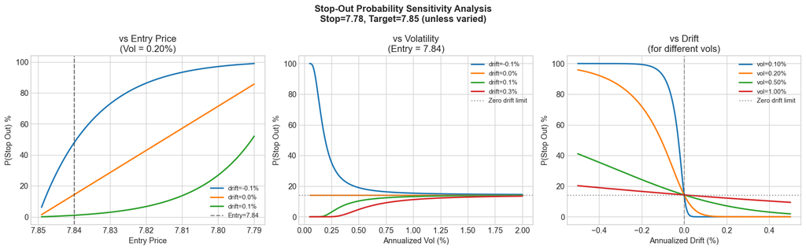

```
Saved: sensitivity_analysis.png
```

```python
fig, axes = plt.subplots(1, 3, figsize=(16, 5))
fig.suptitle("Stop-Out Probability Sensitivity Analysis\n"
             "Stop=7.78, Target=7.85 (unless varied)", fontsize=13, fontweight='bold')

# --- Panel 1: P(stop out) vs Entry Price ---
ax = axes[0]
entries = np.linspace(7.79, 7.849, 200)
p_stop_zero_drift = [(TARGET - e) / (TARGET - STOP) for e in entries]

for drift in [-0.001, 0, 0.001]:
    p_vals = []
    for e in entries:
        if e <= STOP or e >= TARGET:
            p_vals.append(np.nan)
            continue
        try:
            r = prob_stop_out_analytical(e, STOP, TARGET,
                                          annualized_vol=0.002,
                                          annualized_drift=drift)
            p_vals.append(r['p_stop_out'])
        except:
            p_vals.append(np.nan)
    label = f"drift={drift*100:.1f}%"
    ax.plot(entries, [p*100 for p in p_vals], label=label, linewidth=2)

ax.axvline(ENTRY, color='black', linestyle='--', alpha=0.5, label=f'Entry={ENTRY}')
ax.set_xlabel('Entry Price')
ax.set_ylabel('P(Stop Out) %')
ax.set_title('vs Entry Price\n(Vol = 0.20%)')
ax.legend(fontsize=9)
ax.invert_xaxis()  # Higher entry = closer to target = less stop risk

# --- Panel 2: P(stop out) vs Volatility (drift matters when vol changes) ---
ax = axes[1]
vols = np.linspace(0.0005, 0.02, 300)  # 0.05% to 2% annualized

for drift in [-0.001, 0, 0.001, 0.003]:
    p_vals = []
    for v in vols:
        r = prob_stop_out_analytical(ENTRY, STOP, TARGET,
                                      annualized_vol=v,
                                      annualized_drift=drift)
        p_vals.append(r['p_stop_out'])
    ax.plot(vols*100, [p*100 for p in p_vals],
            label=f"drift={drift*100:.1f}%", linewidth=2)

ax.axhline((TARGET - ENTRY)/(TARGET - STOP)*100, color='gray',
           linestyle=':', label='Zero drift limit', alpha=0.8)
ax.set_xlabel('Annualized Vol (%)')
ax.set_ylabel('P(Stop Out) %')
ax.set_title('vs Volatility\n(Entry = 7.84)')
ax.legend(fontsize=9)

# --- Panel 3: P(stop out) vs Drift (for different vols) ---
ax = axes[2]
drifts = np.linspace(-0.005, 0.005, 300)

for iv in [0.001, 0.002, 0.005, 0.01]:
    p_vals = []
    for d in drifts:
        r = prob_stop_out_analytical(ENTRY, STOP, TARGET,
                                      annualized_vol=iv,
                                      annualized_drift=d)
        p_vals.append(r['p_stop_out'])
    ax.plot(drifts*100, [p*100 for p in p_vals],
            label=f"vol={iv*100:.2f}%", linewidth=2)

ax.axvline(0, color='black', linestyle='--', alpha=0.3)
ax.axhline((TARGET - ENTRY)/(TARGET - STOP)*100, color='gray',
           linestyle=':', label='Zero drift limit', alpha=0.8)
ax.set_xlabel('Annualized Drift (%)')
ax.set_ylabel('P(Stop Out) %')
ax.set_title('vs Drift\n(for different vols)')
ax.legend(fontsize=9)

plt.tight_layout()
plt.savefig('sensitivity_analysis.png', bbox_inches='tight', dpi=150)
plt.show()
print("Saved: sensitivity_analysis.png")
```

## 6. Monte Carlo Path Visualization

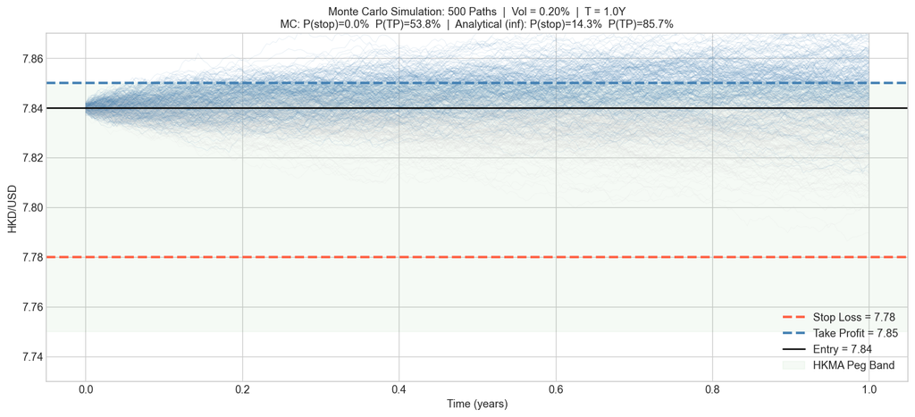

```
Saved: monte_carlo_paths.png
```

```python
np.random.seed(0)
N_PLOT  = 500
IV      = 0.002
T_PLOT  = 1.0
DT      = 1/252
N_STEPS = int(T_PLOT / DT)

sigma_p = IV * ENTRY
Z       = np.random.randn(N_PLOT, N_STEPS)
paths   = ENTRY + np.cumsum(sigma_p * np.sqrt(DT) * Z, axis=1)

# Classify outcome for each path
colors = []
outcomes = {'stop': 0, 'target': 0, 'neither': 0}

for i in range(N_PLOT):
    path = paths[i]
    s = np.where(path <= STOP)[0]
    t = np.where(path >= TARGET)[0]
    fs = s[0] if len(s) > 0 else N_STEPS + 1
    ft = t[0] if len(t) > 0 else N_STEPS + 1
    if fs < ft:
        colors.append('tomato')
        outcomes['stop'] += 1
    elif ft < fs:
        colors.append('steelblue')
        outcomes['target'] += 1
    else:
        colors.append('lightgray')
        outcomes['neither'] += 1

fig, ax = plt.subplots(figsize=(13, 6))
time_axis = np.linspace(0, T_PLOT, N_STEPS)

for i in range(N_PLOT):
    ax.plot(time_axis, paths[i], color=colors[i], alpha=0.12, linewidth=0.6)

ax.axhline(STOP,   color='tomato',    linewidth=2.5, linestyle='--', label=f'Stop Loss = {STOP}')
ax.axhline(TARGET, color='steelblue', linewidth=2.5, linestyle='--', label=f'Take Profit = {TARGET}')
ax.axhline(ENTRY,  color='black',     linewidth=1.5, linestyle='-',  label=f'Entry = {ENTRY}')

# Peg band
ax.axhspan(7.75, 7.85, alpha=0.04, color='green', label='HKMA Peg Band')

p_stop_mc = outcomes['stop'] / N_PLOT
p_tp_mc   = outcomes['target'] / N_PLOT
p_an      = prob_stop_out_analytical(ENTRY, STOP, TARGET, mu=0, annualized_vol=IV)

ax.set_title(
    f"Monte Carlo Simulation: {N_PLOT} Paths  |  Vol = {IV*100:.2f}%  |  T = {T_PLOT}Y\n"
    f"MC: P(stop)={p_stop_mc*100:.1f}%  P(TP)={p_tp_mc*100:.1f}%  |  "
    f"Analytical (inf): P(stop)={p_an['p_stop_out']*100:.1f}%  P(TP)={p_an['p_take_profit']*100:.1f}%",
    fontsize=11
)
ax.set_xlabel('Time (years)')
ax.set_ylabel('HKD/USD')
ax.legend(loc='lower right')
ax.set_ylim(7.73, 7.87)

plt.tight_layout()
plt.savefig('monte_carlo_paths.png', bbox_inches='tight', dpi=150)
plt.show()
print("Saved: monte_carlo_paths.png")
```

## 7. Implied Vol vs Historical Vol: P(Stop Out) Comparison

Traders often have access to:

- **Implied vol** — market's forward-looking expectation (from options prices)
- **Historical vol** — realized vol from past price data

If implied vol > realized vol → options are expensive → the market expects more movement than history suggests. If you believe in historical vol, you'd assign a *different* stop-out probability than the options market implies.

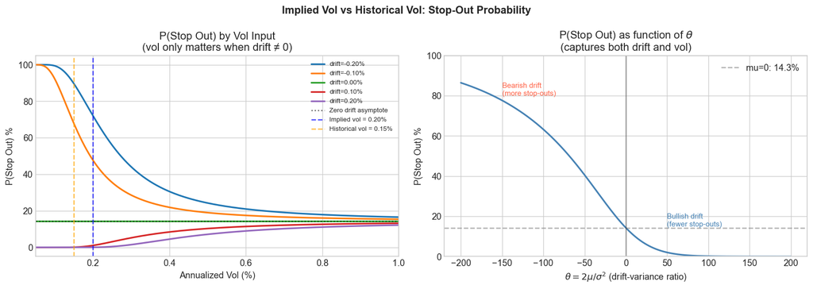

```
Saved: vol_comparison.png
```

```python
def compare_vol_surfaces(entry, stop, target,
                          iv_range=(0.0005, 0.005),
                          hist_vol_range=(0.0005, 0.005),
                          n=80):
    """
    Create a 2D heatmap of P(stop out) across a grid of (implied vol, hist vol).
    Here we use hist vol as the 'true' vol, but label both axes to show
    how your stop-out probability belief changes depending on which vol you use.
    """
    vols = np.linspace(iv_range[0], iv_range[1], n)
    P = np.zeros((n, n))

    for i, v in enumerate(vols):
        r = prob_stop_out_analytical(entry, stop, target, mu=0, annualized_vol=v)
        P[i, :] = r['p_stop_out']  # same formula — depends only on vol

    return vols, P

vols = np.linspace(0.0005, 0.01, 500)
p_vals = [prob_stop_out_analytical(ENTRY, STOP, TARGET, mu=0, annualized_vol=v)['p_stop_out']
          for v in vols]

# --- IMPORTANT: when mu=0, P(stop out) doesn't depend on vol! ---
# Let's show the WITH-DRIFT case where vol matters

fig, axes = plt.subplots(1, 2, figsize=(14, 5))
fig.suptitle("Implied Vol vs Historical Vol: Stop-Out Probability", fontsize=13, fontweight='bold')

# Panel 1: P(stop out) as function of vol for several drifts
ax = axes[0]
for drift in [-0.002, -0.001, 0, 0.001, 0.002]:
    p_vals = [prob_stop_out_analytical(ENTRY, STOP, TARGET, mu=0,
                                        annualized_vol=v,
                                        annualized_drift=drift)['p_stop_out']
              for v in vols]
    ax.plot(vols*100, [p*100 for p in p_vals],
            label=f"drift={drift*100:.2f}%", linewidth=2)

ax.axhline((TARGET-ENTRY)/(TARGET-STOP)*100, color='black',
           linestyle=':', linewidth=1.5, label='Zero drift asymptote', alpha=0.6)

# Mark implied vol (e.g. 0.20%) vs historical vol (e.g. 0.15%)
ax.axvline(0.20, color='blue',   linestyle='--', alpha=0.7, label='Implied vol = 0.20%')
ax.axvline(0.15, color='orange', linestyle='--', alpha=0.7, label='Historical vol = 0.15%')

ax.set_xlabel('Annualized Vol (%)')
ax.set_ylabel('P(Stop Out) %')
ax.set_title('P(Stop Out) by Vol Input\n(vol only matters when drift ≠ 0)')
ax.legend(fontsize=8)
ax.set_xlim(0.05, 1.0)

# Panel 2: theta sensitivity — how drift-vol ratio drives the probability
ax = axes[1]
thetas = np.linspace(-200, 200, 500)
c = ENTRY - STOP    # 0.06
d = TARGET - ENTRY  # 0.01

p_theta = []
for th in thetas:
    if abs(th) < 1e-8:
        p_theta.append(d / (c + d))
    else:
        num   = np.expm1(th * d)
        denom = np.expm1(th * (c + d))
        p_theta.append(num / denom if abs(denom) > 1e-15 else np.nan)

ax.plot(thetas, [p*100 for p in p_theta], color='steelblue', linewidth=2)
ax.axhline(d/(c+d)*100, color='gray', linestyle='--', alpha=0.6, label=f'mu=0: {d/(c+d)*100:.1f}%')
ax.axvline(0, color='black', alpha=0.3)
ax.set_xlabel(r'$\theta = 2\mu/\sigma^2$ (drift-variance ratio)')
ax.set_ylabel('P(Stop Out) %')
ax.set_title(r'P(Stop Out) as function of $\theta$' + '\n(captures both drift and vol)')
ax.legend()
ax.set_ylim(0, 100)

# Annotate: negative theta = bearish = more likely to stop out
ax.annotate('Bearish drift\n(more stop-outs)', xy=(-150, 80), fontsize=9, color='tomato')
ax.annotate('Bullish drift\n(fewer stop-outs)', xy=(50, 15), fontsize=9, color='steelblue')

plt.tight_layout()
plt.savefig('vol_comparison.png', bbox_inches='tight', dpi=150)
plt.show()
print("Saved: vol_comparison.png")
```

## 8. Summary & Key Formulas

### The Formula

For arithmetic BM $dS = \mu\,dt + \sigma\,dW_t$, starting at $S_0$, with stop $L$ and target $U$:

$$\boxed{P(\text{stop out}) = \frac{e^{\theta(U - S_0)} - 1}{e^{\theta(U - L)} - 1}, \quad \theta = \frac{2\mu}{\sigma^2}}$$

**When $\mu = 0$:** $$P(\text{stop out}) = \frac{U - S_0}{U - L} \quad \text{(independent of } \sigma \text{!)}$$

### Applied to the HKD Trade

|  | Value |
| --- | --- |
| Entry $S_0$ | 7.84 |
| Stop $L$ | 7.78 (6 pips below) |
| Target $U$ | 7.85 (1 pip above) |
| $P(\text{stop out}), \mu=0$ | $(7.85 - 7.84)/(7.85 - 7.78) = 0.01/0.07 \approx \mathbf{14.3\%}$ |
| $P(\text{take profit}), \mu=0$ | $\mathbf{85.7\%}$ |

### Critical Insight: The Drift-Vol Ratio $\theta$

- Vol alone (with zero drift) doesn't change $P(\text{stop out})$ — it only determines **how quickly** you hit a barrier
- What matters is $\theta = 2\mu/\sigma^2$: whether your drift is large **relative to your variance**
- For a pegged currency like HKD, $\mu \approx 0$ is a reasonable assumption, so **geometry dominates**: your stop is 6× farther than your target, but you only have a 14.3% chance of getting stopped
- A small negative drift (e.g., dollar strength) rapidly increases $P(\text{stop out})$

### Using Implied vs Historical Vol

- If $\mu = 0$: the two give the **same** $P(\text{stop out})$ regardless of vol level
- If $\mu \neq 0$: a higher vol **dilutes** the drift's effect → $P(\text{stop out}) \to 14.3\%$ as $\sigma \to \infty$
- In practice: use implied vol when you believe the market correctly prices future moves; use historical vol when you think current IV is mispriced

```python
# Quick reference function for any trade
def quick_stop_prob(entry, stop, target, vol, drift=0.0):
    r = prob_stop_out_analytical(entry, stop, target,
                                  annualized_vol=vol, annualized_drift=drift)
    print(f"P(stop out)    = {r['p_stop_out']*100:.2f}%")
    print(f"P(take profit) = {r['p_take_profit']*100:.2f}%")
    print(f"EV (per unit)  = {r['p_take_profit']*(target-entry) - r['p_stop_out']*(entry-stop):.5f}")
    return r

print("Example: Long HKD @ 7.84, stop 7.78, target 7.85, vol=0.20%, drift=0%")
_ = quick_stop_prob(7.84, 7.78, 7.85, vol=0.002)
```

```
Example: Long HKD @ 7.84, stop 7.78, target 7.85, vol=0.20%, drift=0%
P(stop out)    = 14.29%
P(take profit) = 85.71%
EV (per unit)  = 0.00000
```